# pyMódulo 13

Curso IE0217 Estructuras abstractas y algoritmos para ingeniería - UCR

Profesor Freddy Rojas Ch.

1/27/2021

# Lenguaje Python 3 Módulo 13

Se estudian en el módulo 13 de Python ejemplos de aplicación de los métodos K-medias y Clusterización Jerárquica.

## Ejemplo #1

En este problema se va a utilizar un data-set que contienen datos sobre los pasajeros que estaban reportados y que sufrieron la tragedia del Titanic. Se va a desarrollar un análsis que permitirá estimar supervivencia.

Los datos utilizados se encuentran en el archivo: titanic.csv.

La tabla contiene 12 variables y 1309 observaciones, las variables son:

1. PassegerId: El cóigo de identificacón del pasajero (valor único).
2. Survived: Variable (*enumerada*):
- 1 (el pasajero sobrevivio ́)
- 0 (el pasajero no sobrevivio ́).
3. Pclass: En que clase viajaba el pasajero (1 = primera, 2 = segunda , 3 = tercera) (*enumerada*).
4. Name: Nombre del pasajero (valor único).
5. Sex: Sexo del pasajero. (*enumerada*)
6. Age: Edad del pasajero.
7. SibSp: Cantidad de hermanos o cónyuge asocidao al pasajero a bordo del barco.
8. Parch: Cantidad de padres o hijos asociados al pasajero a borde del barco.
9. Ticket: Número de tiquete (valor único).
10. Fare: Tarifa del pasajero.
11. Cabin: Número de cabina (código único) (*enumerada*)
12. Embarked: Puerto donde embarco el pasajero (C = Cherbourg, Q = Queenstown, S = Southampton).(*enumerada*)

Las variables indicadas con (*enumerada*) son variables *ordinales* o *categóricos* y deben ser manipulados como tales antes de hacer cálculos.

En el caso de las variables *PassegerId*, *Cabin* y *Ticket* estas son variables *nominales* y pueden ser usadas eventualmente como una *llave* por su condición de terner valores únicos en estructuras como bases de datos. No tiene sentido calcular valores, como la media, mediana o desviación estándar con estas variables.

### Librerías y funciones de apoyo

```python
import pandas as pd
import numpy as np
from   math import pi
import matplotlib.pyplot as plt
from   sklearn.decomposition import PCA
from   sklearn.cluster import KMeans

from scipy.cluster.hierarchy import dendrogram, ward, single, complete,average,linkage, fcluster
from scipy.spatial.distance import pdist
```

```python
def Plot():
    plt.show()
    plt.close()
```

```python
def centroide(num_cluster, datos, clusters):
  ind = clusters == num_cluster
  return(pd.DataFrame(datos[ind].mean()).T)

datos = pd.read_csv('../Datos/titanic.csv',delimiter=',',decimal=".",index_col =0)
datos=datos.dropna()
print(datos.head(10))
```

```
##              Survived  Pclass  ...        Cabin Embarked
## PassengerId                    ...
## 2                   1       1  ...          C85        C
## 4                   1       1  ...         C123        S
## 7                   0       1  ...          E46        S
## 11                  1       3  ...           G6        S
## 12                  1       1  ...         C103        S
## 22                  1       2  ...          D56        S
## 24                  1       1  ...           A6        S
## 28                  0       1  ...  C23 C25 C27        S
## 53                  1       1  ...          D33        C
## 55                  0       1  ...          B30        C
##
## [10 rows x 11 columns]
```

### Análisis de archivo

En este segmento de código se convierten a categóricas variables que originalmente tienen valores numéricos pero su significado es cualitativo. Se eliminan las variables que no se requieren dejando el data frame listo para la exploración.

```python
print("Análsis de archivo")
```

```
## Análsis de archivo
```

```python
print("+++++++++++++++++++++")
```

```
## +++++++++++++++++++++
```

```python
print(datos.dtypes)

#Nombres de variables
```

```
## Survived      int64
## Pclass        int64
## Name         object
## Sex          object
## Age         float64
## SibSp         int64
## Parch         int64
## Ticket       object
## Fare        float64
## Cabin        object
## Embarked     object
## dtype: object
```

```python
NombreTodasVar=datos.columns.values.tolist()
print("Nombre de todas las variables \n%s" % NombreTodasVar)

#Convertir a categóricas las tipo 'object'
```

```
## Nombre de todas las variables
## ['Survived', 'Pclass', 'Name', 'Sex', 'Age', 'SibSp', 'Parch', 'Ticket', 'Fare', 'Cabin', 'Embarked']
```

```python
lista_categoricas=['Ticket','Cabin','Survived', 'Pclass', 'Sex']
for nombre in lista_categoricas:
    datos[nombre]=datos[nombre].astype('category')

Survived=datos['Survived']
#Borrar variables ID y no trascendentales
lista_borrar=[ 'Name', 'Ticket','Cabin','Survived', 'Pclass', 'Sex','Embarked']
datos=datos.drop(lista_borrar,axis=1)

#Todas las variables ajustadas.
NombreTodasVar= datos.columns.values.tolist()
print("Nombre de todas las variables sin ID's \n%s" % NombreTodasVar)
```

```
## Nombre de todas las variables sin ID's
## ['Age', 'SibSp', 'Parch', 'Fare']
```

```python
df_numericas = datos.select_dtypes(include=['float64','int64'])
NombresNumericas=df_numericas.columns.values.tolist()
print("Nombre de variables numéricas \n%s" % NombresNumericas)
```

```
## Nombre de variables numéricas
## ['Age', 'SibSp', 'Parch', 'Fare']
```

### Clusterización Jerárquica.

Se construyen las instancias para: salto mínimo, salto máximo, promedio y ”Ward”. Luego se procede a generar los gráficos de los dendogramas.

#### Dendogramas

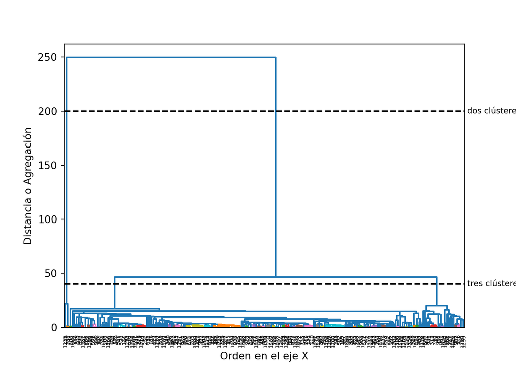

```python
### CLUSTERING JERARQUICO
single_res = single(datos)          #Salto mínimo
complete_res = complete(datos)      #Salto Máximo
average_res = average(datos)        #Promedio
ward_res = ward(datos)              #Ward

## Dendogramas
null=dendrogram(single_res,color_threshold=3,labels= datos.index.tolist())
ax = plt.gca()
limites = ax.get_xbound()
ax.plot(limites, [200, 200], '--', c='k')
ax.text(limites[1], 200, ' dos clústeres', va='center', fontdict={'size': 8})
ax.plot(limites, [40, 40], '--', c='k')
ax.text(limites[1], 40, ' tres clústeres', va='center', fontdict={'size': 8})
plt.xlabel("Orden en el eje X")
plt.ylabel("Distancia o Agregación")
Plot()
```

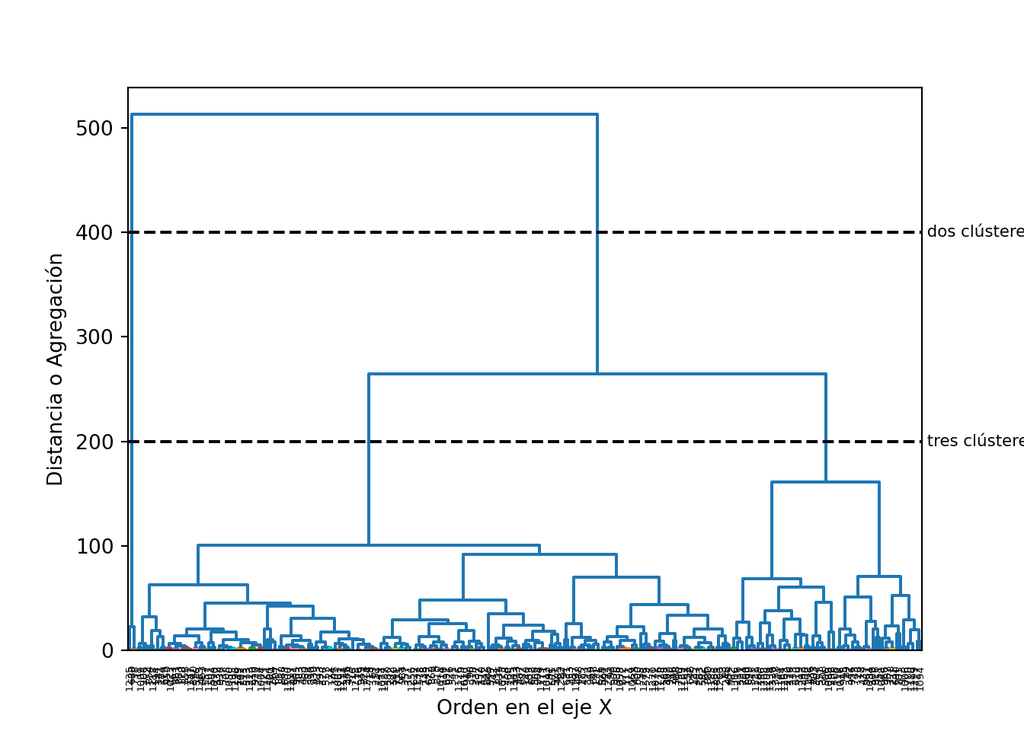

```python
null=dendrogram(complete_res,color_threshold=3,labels= datos.index.tolist())
ax = plt.gca()
limites = ax.get_xbound()
ax.plot(limites, [400, 400], '--', c='k')
ax.text(limites[1], 400, ' dos clústeres', va='center', fontdict={'size': 8})
ax.plot(limites, [200, 200], '--', c='k')
ax.text(limites[1], 200, ' tres clústeres', va='center', fontdict={'size': 8})
plt.xlabel("Orden en el eje X")
plt.ylabel("Distancia o Agregación")
Plot()
```

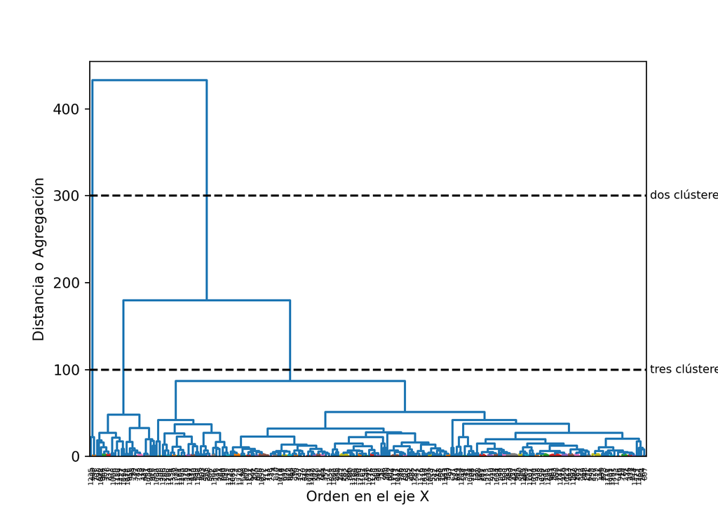

```python
null=dendrogram(average_res,color_threshold=3,labels= datos.index.tolist())
ax = plt.gca()
limites = ax.get_xbound()
ax.plot(limites, [300, 300], '--', c='k')
ax.text(limites[1], 300, ' dos clústeres', va='center', fontdict={'size': 8})
ax.plot(limites, [100, 100], '--', c='k')
ax.text(limites[1], 100, ' tres clústeres', va='center', fontdict={'size': 8})
plt.xlabel("Orden en el eje X")
plt.ylabel("Distancia o Agregación")
Plot()
```

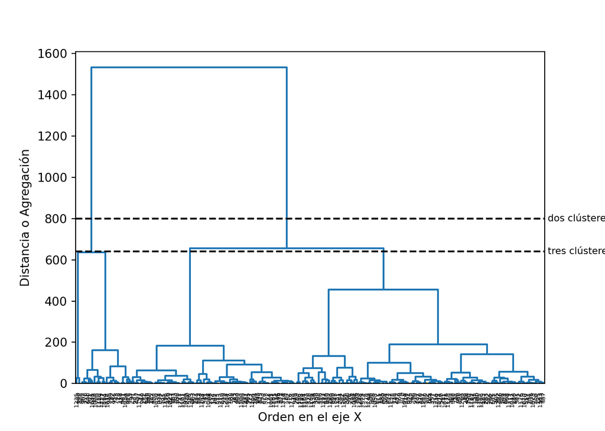

```python
null=dendrogram(ward_res,color_threshold=2,labels= datos.index.tolist())
ax = plt.gca()
limites = ax.get_xbound()
ax.plot(limites, [800, 800], '--', c='k')
ax.text(limites[1], 800, ' dos clústeres', va='center', fontdict={'size': 8})
ax.plot(limites, [640, 640], '--', c='k')
ax.text(limites[1], 640, ' tres clústeres', va='center', fontdict={'size': 8})
plt.xlabel("Orden en el eje X")
plt.ylabel("Distancia o Agregación")
Plot()
```

En el dendograma de salto mínimo para la partición de dos clusters se puede observar que genera un grupo pequeño de pocos pasajeros de un lado mientras del otro la casi totalidad de los pasajeros, a este punto no se puede concluir mucho. Para el corte de tres ramas se de nuevo una rama con pocos pasajeros, y las otras dos ramas una de ellas con gran cantidad de pasajeros, tampoco ofrece información muy relevante.

Para el dendograma de salto máximo se puede observar, con una partición de dos ramas se tiene la misma condición de salto mínimo, pero para tres ramas el balance de pasajeros es más selectivo. Para este caso si se toma la lista de cada una de las tres ramas se podrían afinar otros estudios mejor clasificados.

Para salto promedio la situación es muy similar a salto mínimo. Para salto de ward la condición es más semejante al caso de salto máximo.

#### Gráficos de barras

Se ejecuta el siguiente código para obtener los gráficos de barras para agregación de ward y usando dos clusters.

```python
#BAR plot
grupos = fcluster(linkage(pdist(datos), method='ward'),2,criterion='maxclust')
print(grupos)
```

```
## [2 2 2 2 2 2 2 1 2 2 2 2 2 1 2 2 2 2 2 1 2 2 2 2 2 2 2 2 2 2 2 2 2 2 2 2 2
##  2 2 2 2 2 2 2 2 2 2 2 2 2 2 2 2 2 1 2 2 2 2 1 2 2 2 2 2 2 2 2 2 2 2 1 2 2
##  2 2 2 1 2 2 2 2 2 2 2 2 1 2 2 2 2 2 2 2 2 2 2 2 2 2 2 2 2 2 2 2 2 2 2 2 2
##  2 2 2 2 2 2 2 2 2 2 2 2 2 2 2 2 2 2 2 2 2 2 2 2 2 2 1 2 1 2 2 2 1 2 2 2 2
##  2 1 2 2 1 1 2 1 2 2 2 2 2 2 2 1 2 2 2 2 2 2 2 2 2 2 2 2 2 2 2 2 2 2 2 2 2
##  1 2 2 2 2 2 2 2 1 2 1 1 2 1 2 1 1 2 1 2 2 2 2 2 1 2 2 2 2 1 2 1 2 2 2 2 2
##  2 2 1 2 1 2 2 1 2 2 2 2 2 2 2 2 2 2 2 2 2 2 2 2 2 2 2 2 2 1 2 2 2 2 2 2 2
##  2 2 2 2 2 2 2 2 1 2 2]
```

```python
centros = np.array(   pd.concat([centroide(1,datos,grupos),
                                 centroide(2,datos,grupos) ])  )
print(centros)
```

```
## [[ 37.140625     0.90625      1.21875    264.72578437]
##  [ 36.78327731   0.45378151   0.37815126  60.76960882]]
```

```python
colores_1 = ['#CF8EF8', '#523C81', '#D2D132', '#59C951', '#E5826C']

# Plotea Centro 1
plt.subplot(1, 2, 1)
y  = centros[:1, :].tolist()[0]
plt.bar(range(len(y)), y, 1/1.5, color=colores_1)
```

```
## <BarContainer object of 4 artists>
```

```python
null=plt.xticks(range(datos.shape[1]), datos.columns)

# Plotea Centro 2
plt.subplot(1, 2, 2)
y= centros[1:2, :].tolist()[0]
plt.bar(range(len(y)), y, 1/1.5, color=colores_1)
```

```
## <BarContainer object of 4 artists>
```

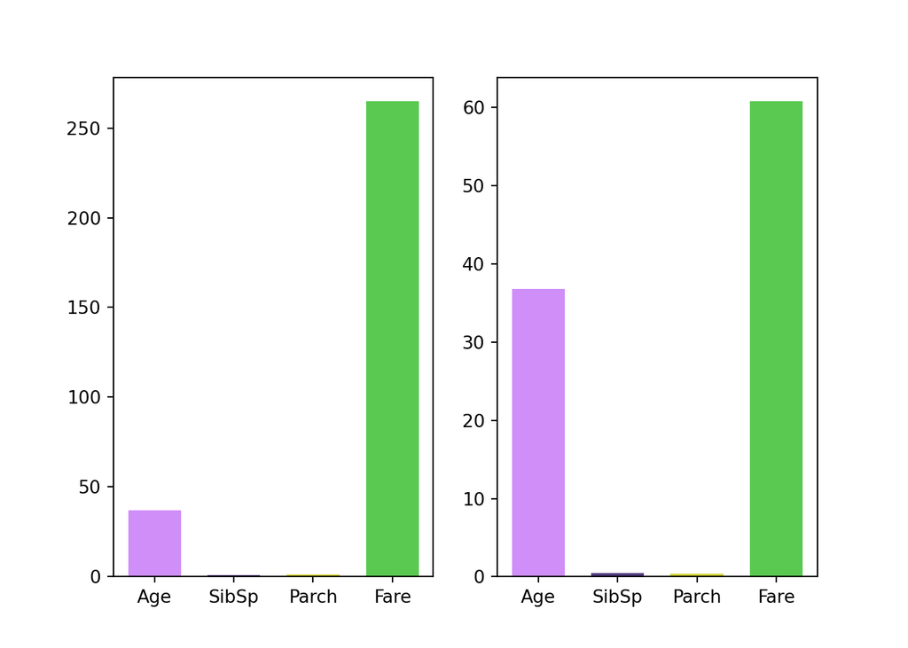

```python
null=plt.xticks(range(datos.shape[1]), datos.columns)
Plot()
```

Para ambos casos los pasajeros con hermanos o con padres es relativamente bajo para ambos grupos de clasificación.

#### Gráfico de radar

Ahora se procede con el siguiente código a generar los gráficos de radar para este caso.

```python
#Radar plot
centros_trans = centros.T
df = pd.DataFrame()
for i in range(datos.shape[1]):
    df = pd.concat([df,pd.DataFrame({datos.columns[i]:centros_trans[i,:].tolist()})],
                   axis = 1)
df =  pd.concat([df,pd.DataFrame(  {'grupo': ['Cluster-1','Cluster-2'] } )],
                axis = 1)
print(df)
```

```
##          Age     SibSp     Parch        Fare      grupo
## 0  37.140625  0.906250  1.218750  264.725784  Cluster-1
## 1  36.783277  0.453782  0.378151   60.769609  Cluster-2
```

```python
maximo=df.max(axis=1).max()
variables=list(df)[0:datos.shape[1]]
print(variables)
```

```
## ['Age', 'SibSp', 'Parch', 'Fare']
```

```python
N = len(variables)
angulos = [n / float(N) * 2 * pi for n in range(N)]
angulos+= angulos[:1]

#Generación de Radar
ax = plt.subplot(111, polar=True)
ax.set_theta_offset(pi / 2)
ax.set_theta_direction(-1)
null=plt.xticks(angulos[:-1], variables)
ax.set_rlabel_position(0)
lista=np.arange(1,11)*int(maximo/10)
lista_p=lista.astype(str)
null=plt.yticks(lista, lista_p, color="grey", size=7)
plt.ylim(0,maximo)

#Cluster 1
```

```
## (0.0, 264.725784375)
```

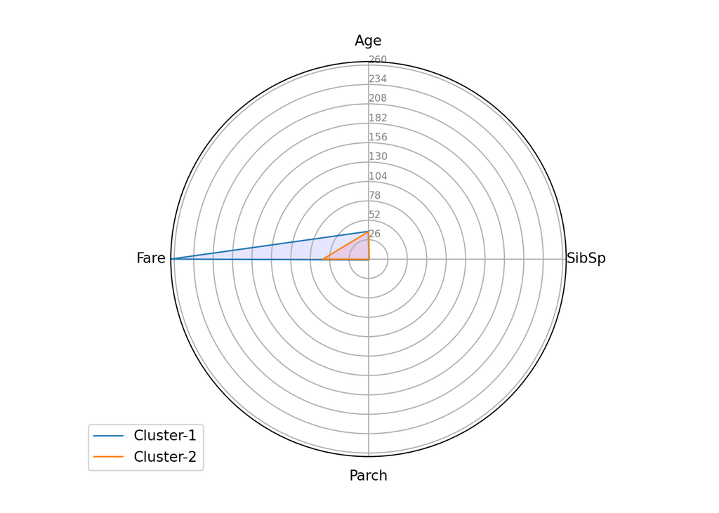

```python
valores=df.loc[0].drop('grupo').values.flatten().tolist()
valores += valores[:1]
ax.plot(angulos, valores, linewidth=1, linestyle='solid', label="Cluster-1")
ax.fill(angulos, valores, 'b', alpha=0.1)

#Cluster 2
valores=df.loc[1].drop('grupo').values.flatten().tolist()
valores += valores[:1]
ax.plot(angulos, valores, linewidth=1, linestyle='solid', label="Cluster-2")
ax.fill(angulos, valores, 'r', alpha=0.1)

plt.legend(loc='upper right', bbox_to_anchor=(0.1, 0.1))

Plot()
```

#### Comparación con componentes principales sobre Clusterización Jerárquica

Usando colores sobre las dos primeras componentes principales del Análisis en Componentes Principales (ACP) se procede a graficar sobre los resultados de Clusterización Jerárquica.

```python
#PCA 2 componentes todos
pca = PCA(n_components=2)
componentes = pca.fit_transform(datos)
#print(componentes)
print(datos.shape)
```

```
## (270, 4)
```

```python
print(componentes.shape)
```

```
## (270, 2)
```

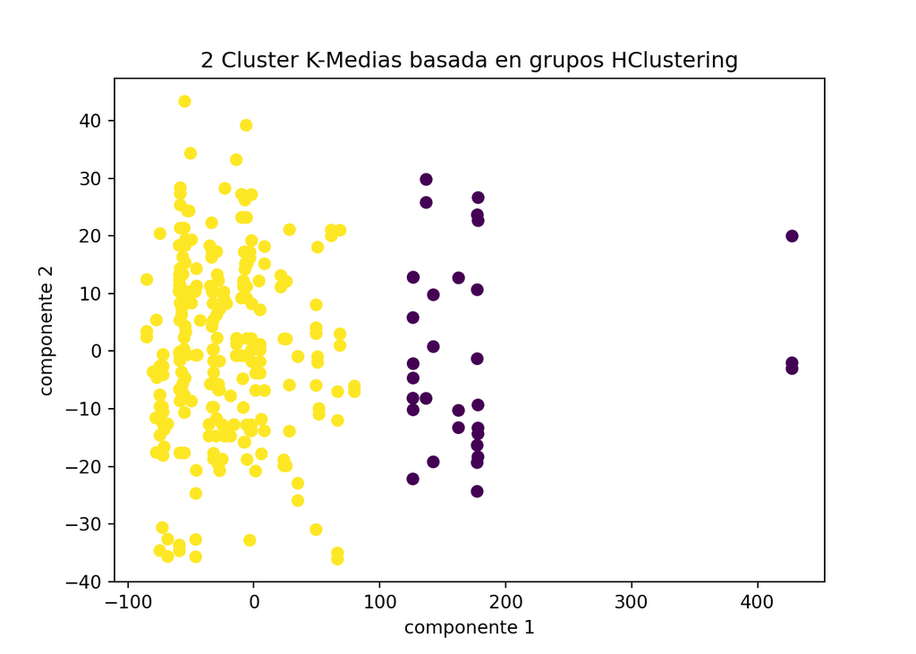

```python
plt.scatter(componentes[:, 0], componentes[:, 1],c=grupos)
plt.xlabel('componente 1')
plt.ylabel('componente 2')
plt.title('2 Cluster K-Medias basada en grupos HClustering')
Plot()

#PCA 2 componentes Survived
```

```python
print("Survived")
```

```
## Survived
```

```python
print(Survived)
```

```
## PassengerId
## 2       1
## 4       1
## 7       0
## 11      1
## 12      1
##        ..
## 1296    0
## 1297    0
## 1299    0
## 1303    1
## 1306    1
## Name: Survived, Length: 270, dtype: category
## Categories (2, int64): [0, 1]
```

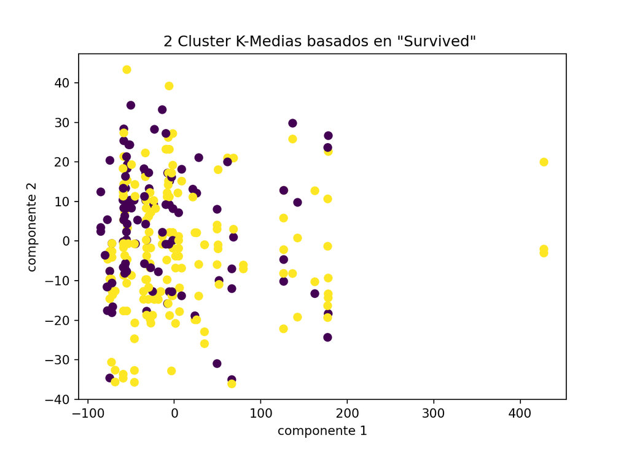

```python
plt.scatter(componentes[:, 0], componentes[:, 1],c=Survived)
plt.xlabel('componente 1')
plt.ylabel('componente 2')
plt.title('2 Cluster K-Medias basados en "Survived" ')
Plot()
```

Los gráficos resultantes se observan en el detalle anterior. Se puede concluir que efectivamente se ven definidos dos grupos de pasajeros, uno asociado a una mayor cantidad de casos.

### Estudio K medias

El código para realizar el análisis con K medias es el siguiente:

```python
#K medias
kmedias = KMeans(n_clusters=2)
kmedias.fit(datos)
```

```
## KMeans(n_clusters=2)
```

```python
print(kmedias.predict(datos))
```

```
## [0 0 0 0 0 0 0 1 0 0 0 0 0 1 0 0 0 0 0 1 0 0 0 0 0 0 0 0 0 0 0 0 0 0 0 0 0
##  0 0 0 0 0 0 0 0 0 0 0 0 0 0 0 0 0 1 0 0 0 0 1 1 0 0 0 0 0 0 0 0 0 0 1 0 0
##  0 0 0 1 0 0 0 0 0 0 0 0 1 0 0 0 0 0 0 0 0 0 0 0 0 0 0 0 0 0 0 0 0 0 0 0 0
##  0 0 0 0 0 0 0 0 0 0 0 0 0 0 0 0 0 0 0 0 0 0 0 0 0 0 1 0 1 0 0 0 1 0 0 0 0
##  0 1 0 0 1 1 0 1 0 0 0 0 0 0 0 1 0 0 0 0 0 0 0 0 0 0 0 0 0 0 0 0 0 0 0 0 0
##  1 0 0 0 0 0 0 0 1 0 1 1 0 1 0 1 1 0 1 0 0 0 0 0 1 0 0 0 0 1 0 1 0 0 0 0 0
##  0 0 1 0 1 0 0 1 0 0 0 0 0 0 0 0 0 0 0 0 0 0 0 0 0 0 0 0 0 1 0 0 0 0 0 0 0
##  0 0 0 0 0 1 0 0 1 0 0]
```

```python
centros = np.array(kmedias.cluster_centers_)
print(centros)

#Bar plot
```

```
## [[ 36.83652542   0.45762712   0.37288136  59.88743008]
##  [ 36.75         0.85294118   1.20588235 258.85172059]]
```

```python
colores_1 = ['#CF8EF8', '#523C81', '#D2D132', '#59C951', '#E5826C']
#plt.figure(1,figsize=(25,15))

# Plotea Centro 1
plt.subplot(1, 2, 1)
y  = centros[:1, :].tolist()[0]
plt.bar(range(len(y)), y, 1/1.5, color=colores_1)
```

```
## <BarContainer object of 4 artists>
```

```python
null=plt.xticks(range(datos.shape[1]), datos.columns)

# Plotea Centro 2
plt.subplot(1, 2, 2)
y= centros[1:2, :].tolist()[0]
plt.bar(range(len(y)), y, 1/1.5, color=colores_1)
```

```
## <BarContainer object of 4 artists>
```

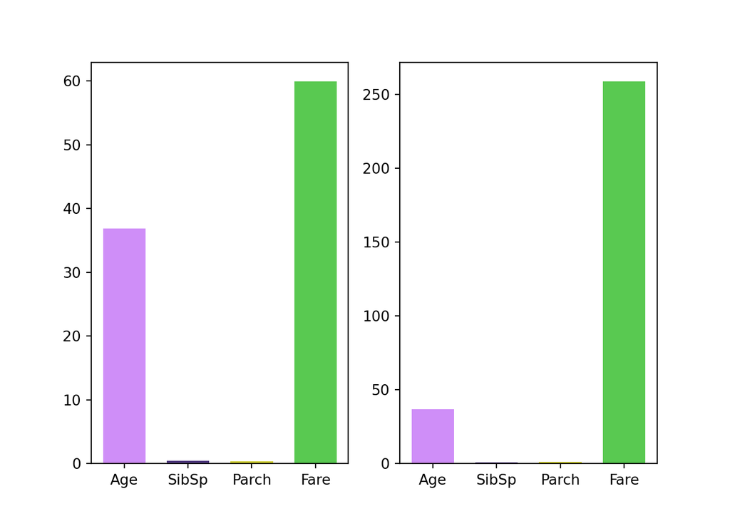

```python
null=plt.xticks(range(datos.shape[1]), datos.columns)

Plot()
```

Se observa en las figuras anteriores un resultado muy similar al desarrollado con Clusterización Jerárquica.

#### Gráficos radar del análisis K-medias

El gráfico de radar se confecciona con este código:

```python
#Radar plot
centros_trans = centros.T
df = pd.DataFrame()
for i in range(datos.shape[1]):
    df = pd.concat([df,pd.DataFrame({datos.columns[i]:centros_trans[i,:].tolist()})],
                   axis = 1)
df =  pd.concat([df,pd.DataFrame(  {'grupo': ['Cluster-1','Cluster-2'] } )],
                axis = 1)
print(df)
```

```
##          Age     SibSp     Parch        Fare      grupo
## 0  36.836525  0.457627  0.372881   59.887430  Cluster-1
## 1  36.750000  0.852941  1.205882  258.851721  Cluster-2
```

```python
maximo=df.max(axis=1).max()
variables=list(df)[0:datos.shape[1]]

print(variables)
```

```
## ['Age', 'SibSp', 'Parch', 'Fare']
```

```python
N = len(variables)
angulos = [n / float(N) * 2 * pi for n in range(N)]
angulos+= angulos[:1]

#Generación de Radar
ax = plt.subplot(111, polar=True)
ax.set_theta_offset(pi / 2)
ax.set_theta_direction(-1)
null=plt.xticks(angulos[:-1], variables)
ax.set_rlabel_position(0)
lista=np.arange(1,11)*int(maximo/10)
lista_p=lista.astype(str)
null=plt.yticks(lista, lista_p, color="grey", size=7)
plt.ylim(0,maximo)

#Cluster 1
```

```
## (0.0, 258.8517205882353)
```

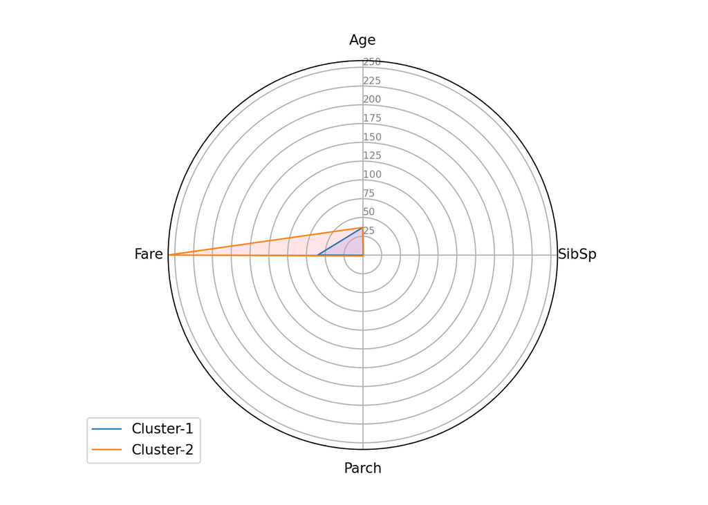

```python
valores=df.loc[0].drop('grupo').values.flatten().tolist()
valores += valores[:1]
ax.plot(angulos, valores, linewidth=1, linestyle='solid', label="Cluster-1")
ax.fill(angulos, valores, 'b', alpha=0.1)

#Cluster 2
valores=df.loc[1].drop('grupo').values.flatten().tolist()
valores += valores[:1]
ax.plot(angulos, valores, linewidth=1, linestyle='solid', label="Cluster-2")
ax.fill(angulos, valores, 'r', alpha=0.1)

plt.legend(loc='upper right', bbox_to_anchor=(0.1, 0.1))

Plot()
```

Los resultados son prácticamente los mismos del estudio de Clusterización Jerárquica.

#### Comparación con componentes principales sobre K medias

Usando colores sobre las dos primeras componentes principales del Análisis en Componentes Principales (ACP) se procede a graficar sobre los resultados de K/medias

```python
#PCA 2 componentes

pca = PCA(n_components=2)
componentes = pca.fit_transform(datos)
#print(componentes)
print(datos.shape)
```

```
## (270, 4)
```

```python
print(componentes.shape)
```

```
## (270, 2)
```

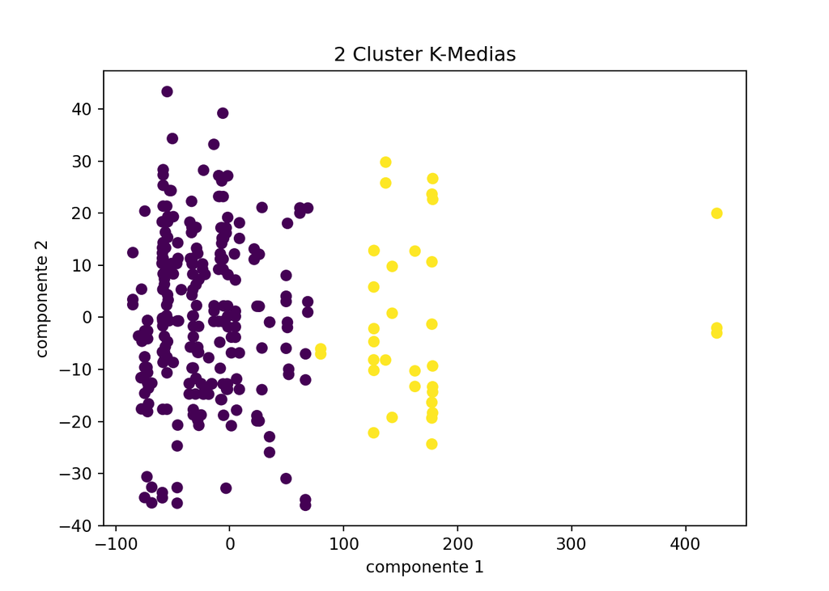

```python
plt.scatter(componentes[:, 0], componentes[:, 1],c=kmedias.predict(datos))
plt.xlabel('componente 1')
plt.ylabel('componente 2')
plt.title('2 Cluster K-Medias')
Plot()

#PCA 2 componentes Survived
```

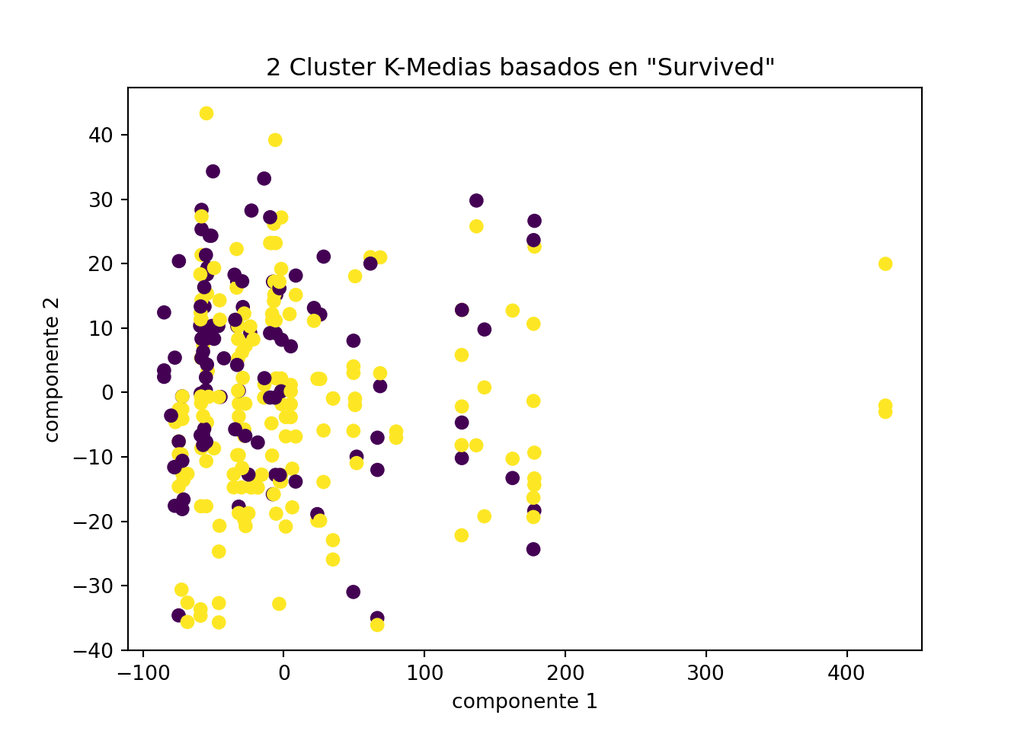

```python
plt.scatter(componentes[:, 0], componentes[:, 1],c=Survived)
plt.xlabel('componente 1')
plt.ylabel('componente 2')
plt.title('2 Cluster K-Medias basados en "Survived" ')
Plot()
```

El plano principal es bastante similar al estudio desarrollado anteriormente. También se observarn los mismos resultados al aplicar la distribución de la variable *survived*.

#### Codo de Jambú

El gráfico para el codo de Jambú se muestra en el siguiente segmento de código:

```python
#Codo de Jambú
print("Codo de Jambú inercia interclases")
```

```
## Codo de Jambú inercia interclases
```

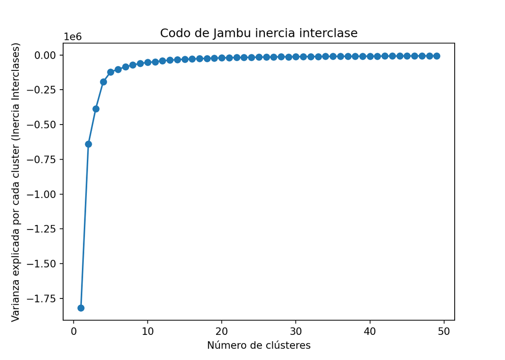

```python
Nc = range(1, 50)
kmediasList = [KMeans(n_clusters=i) for i in Nc]
varianza = [kmediasList[i].fit(datos).score(datos)
            for i in range(len(kmediasList))]
plt.plot(Nc,varianza,'o-')
plt.xlabel('Número de clústeres')
plt.ylabel('Varianza explicada por cada cluster (Inercia Interclases)')
plt.title('Codo de Jambu inercia interclase')
Plot()
```

```python
print("Codo de Jambú inercia intraclases")
```

```
## Codo de Jambú inercia intraclases
```

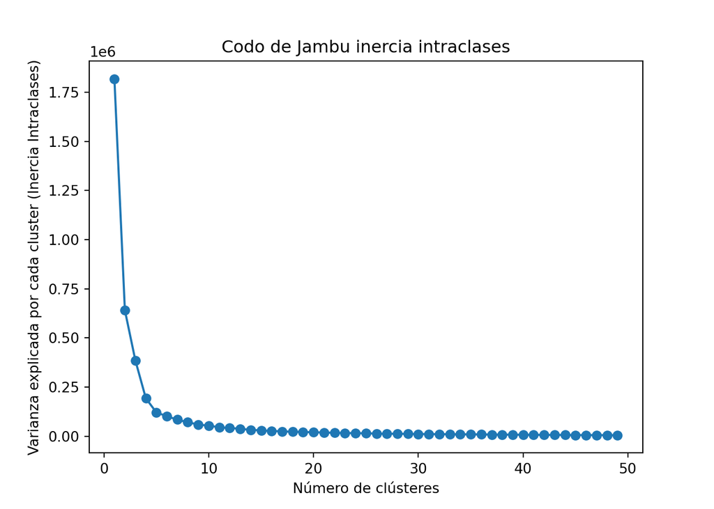

```python
Nc = range(1, 50)
kmediasList = [KMeans(n_clusters=i) for i in Nc]
varianza = [kmediasList[i].fit(datos).inertia_
            for i in range(len(kmediasList))]
plt.plot(Nc,varianza,'o-')
plt.xlabel('Número de clústeres')
plt.ylabel('Varianza explicada por cada cluster (Inercia Intraclases)')
plt.title('Codo de Jambu inercia intraclases')
plt.show()
```

Se puede observar para ambas figuras que el “codo” se estabiliza en 5.